# EXPERIMENT 1: Characterization of Maximal Bicliques using the Consensus Algorithm

In this Experiment we run the implementation of maximal biclique enumeration algorithm from Alexe et al. (http://citeseer.nj.nec.com/alexe02consensus.html)

biclique2.h: The implementation of the algorithm named Consensus Algorithm.

sbtest_ii.cpp: The main program to handle the file input/output.

To **compile** it (under Linux or Mac OSX), simply use the command:  
$ g++ -o sbtest sbtest_ii.cpp

To **run** it, use the command line (all the file names are mandatory):  
$ sbtest [input bigraph file] [output bclique file] [output size file]

**A bipartite graph has two node sets, say X and Y. Each edge is represented by a node x from X and a node y from Y.**

The **input file** consists of a list of edges where x is in the first column and y is in the second column.  
For example:  
2 2  
2 3  
2 4  
3 1  
3 2  
3 3

In the **output file**, each biclique is represented by 3 lines:  
[list of nodes from 1st node set]  
[list of nodes from 2nd node set]  
[empty line]  
For example:  
3  
1 2 3

2 3  
2 3

2  
2 3 4

### We have input in the form of Spice-Disease association data as shown below:

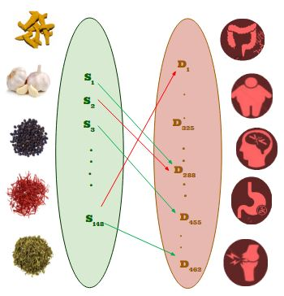

```python
from IPython.display import Image
Image(filename='spice-disease-association.jpg')
```

The Green lines show positive association whereas red show positive associations. We have worked first only on positive associtaions. To conduct a multi-level analysis,spices are associated with disease terms at three levels of MeSH hierarchy labeled as ‘category’, ‘sub-category’ and a ‘disease’. As of now to enumerate maximal bicliques we are focusing on the third level.

So first we map each spice and a disease with a unique numeric value to make the EDGE file as an input for the experiment as explained above. For that we use the below code:

```python
class Spice:
    def __init__(self, id, name):
        self.id = id
        self.name = name


class Disease:
    def __init__(self, id, name):
        self.id = id
        self.name = name


my_file = open('level-3-asssociations.tsv','r')
lines = my_file.readlines()

spices = []
diseases = []
for line in lines:
    temp_list = line.split('\t')
    spices.append(temp_list[1])
    diseases.append(temp_list[3])

# spices.pop(0)
# diseases.pop(0)
spices = list(set(spices))
diseases = list(set(diseases))

disease_mapped_list = []
i = 0
for d in diseases:
    disease = Disease(i, d)
    disease_mapped_list.append(disease)
    i += 1

spice_mapped_list = []
i = len(diseases)
for s in spices:
    spice = Spice(i, s)
    spice_mapped_list.append(spice)
    i += 1

j = 0
for s in spice_mapped_list:
    if j == 0:
        my_spice_file = open('Spice.txt', 'w')
        my_spice_file.write(str(s.id) + ' ' + s.name + '\n')
        j += 1
    else:
        my_spice_file = open('Spice.txt', 'a')
        my_spice_file.write(str(s.id) + ' ' + s.name + '\n')
j = 0
for d in disease_mapped_list:
    if j == 0:
        my_spice_file = open('Disease.txt', 'w')
        my_spice_file.write(str(d.id) + ' ' + d.name + '\n')
        j += 1
    else:
        my_spice_file = open('Disease.txt', 'a')
        my_spice_file.write(str(d.id) + ' ' + d.name + '\n')

edge = []
for line in lines:
    temp_list = line.split('\t')
    spice_name = temp_list[1]
    disease_name = temp_list[3]
    if spice_name == 'Spice' and disease_name == 'Disease':
        continue
    for s in spice_mapped_list:
        if s.name == spice_name:
            spice_id = s.id
    for d in disease_mapped_list:
        if d.name == disease_name:
            disease_id = d.id
    el = []
    el.append(spice_id)
    el.append(disease_id)
    edge.append(el)

j = 0
for e in edge:
    if j == 0:
        my_edge_file = open('Edge-negative.txt', 'w')
        my_edge_file.write(str(e[0]) + ' ' + str(e[1]) + '\n')
        j += 1
    else:
        my_edge_file = open('Edge-negative.txt', 'a')
        my_edge_file.write(str(e[0]) + ' ' + str(e[1]) + '\n')
```

Below is the edge text file that we obtain to pass it as an input to the Maximal Biclique Algorithm.

| Spice | Edge |
| --- | --- |
| 24 | 174 |
| 15 | 174 |
| 71 | 174 |
| 46 | 174 |
| 40 | 174 |
| 125 | 174 |
| 64 | 174 |
| 124 | 174 |
| 18 | 174 |
| 34 | 174 |
| 97 | 174 |
| 61 | 174 |
| 31 | 174 |
| 92 | 174 |
| 23 | 174 |
| 27 | 174 |
| 94 | 174 |

```python
import numpy as np
data= np.loadtxt('Edge.txt')
print(data)
```

```
[[  24.  174.]
 [  15.  174.]
 [  71.  174.]
 ...,
 [ 118.  451.]
 [ 130.  451.]
 [  63.  451.]]
```

After running the algorithm we get an output of the form we stated above. We then demap the output to get the results in the form of spice and disease names.

Below is the code that is used to demap the bicliques to their respective spice names and disease names.

```python
spices = {}
my_spice_file = open('Spice.txt', 'r')
spice_lines = my_spice_file.readlines()
for line in spice_lines:
    temp_list = line.split(' ', 1)
    spices[temp_list[0].strip()] = temp_list[1].strip()

diseases = {}
my_disease_file = open('Disease.txt', 'r')
disease_lines = my_disease_file.readlines()
for line in disease_lines:
    temp_list = line.split(' ', 1)
    diseases[temp_list[0].strip()] = temp_list[1].strip()

biclique = []

controller = 1
f = open('biclique.out', 'r')
lines = f.readlines()
for line in lines:
    s = []
    d = []
    if controller == 1:
        temp = line.split()
        if len(temp) == 1:
            s.append(spices[temp[0]])
        else:
            temp = line.split()
            for t in temp:
                s.append(spices[t])
        biclique.append(s)
        controller = 2
    elif controller == 2:
        temp = line.split()
        if len(temp) == 1:
            d.append(diseases[temp[0]])
        else:
            temp = line.split()
            for t in temp:
                d.append(diseases[t])
        biclique.append(d)
        controller = 3
    else:
        controller = 1

out_file = open('Demapped_file_without_bnumbr.txt', 'w')
counter = 1

controller = 1
for db in biclique:
    print (counter)
    if controller == 1:
        mc = 0
        # out_file.write(str(counter) + ' ')
        for elt in db:
            if mc == len(db) - 1:
                out_file.write(str(elt))
            else:
                out_file.write(str(elt) + ';')
                mc += 1

        out_file.write(':')
        controller = 2
    else:
        mc = 0
        for elt in db:
            if mc == len(db) - 1:
                out_file.write(str(elt))
            else:
                out_file.write(str(elt) + ';')
                mc += 1
        out_file.write('\n')
        controller = 1
        counter += 1
print('Done')
```

The output that we obtain is of the form:

| Set of Spices | : Set of Diseases |
| --- | --- |
| Lavandula angustifolia;Carum carvi | :Dysbiosis |
| Zingiber officinale;Curcuma longa;Nigella sativa;Allium sativum;Uvaria chamae | :Trematode Infections;Body Weight |
| Cinnamomum verum;Zingiber officinale;Orchis mascula;Ginkgo biloba;Mentha x piperita | :Neoplastic Syndromes, Hereditary |
| Orchis mascula;Ginkgo biloba | :Necrosis;Neoplastic Syndromes, Hereditary;Chemical and Drug Induced Liver Injury |
| Nardostachys jatamansi;Borago officinalis;Curcuma longa;Glycyrrhiza glabra;Ginkgo biloba;Mentha spicata;Sesamum indicum | :Lung Injury |

```python
import numpy as np
data= np.loadtxt('Demapped_file_without_bnumbr.txt',delimiter = '\t' , dtype = str , comments = None)
print(data)
```

## So with all the information of the bicliques we have, we perform the following analysis:

### Case 1:

#### Analysis of the biclique size(Number of spices + Number of diseases):

Cumulative distribution of the biclique size was obtained as shown and the results were compared with the histogram of frequency of spice and diseases. The inferences were in complete agreement with each other, with the consensus that the bicliques obtained with very high and very small biclique size are very few in number with most of the bicliques having average sizes. For instance, the percentage of bicliques having biclique size from 0 to 15 are just 4% of the total number of bicliques. Also, the percentage of bicliques having biclique size from 50 to 100 are just 0.5% of the total bicliques as the percentage of bicliques rose from approximately 75% to 75.5%.

```python
import plotly.plotly as py
from plotly.graph_objs import *
import plotly
import plotly.plotly as py
import plotly.figure_factory as ff
import pandas as pd
import numpy as np
import plotly.graph_objs as go

plotly.tools.set_credentials_file(username='akshita17143', api_key='lEzWov2Hr4N7UqlIxkWG')

df = pd.read_csv('data_sorted_on_biclique_size.csv', sep = ',')
df.apply(pd.to_numeric, errors='ignore')
x = df['Spice_Disease_count'].values.tolist()

cumsum = np.cumsum(x)
print(cumsum)
trace = go.Scatter(x=df['Spice_Disease_count'], y=100*cumsum/np.linalg.norm(cumsum),
                     marker=dict(color='rgb(150, 25, 120)'))

layout = go.Layout(xaxis=dict(title='Biclique_size'),
                yaxis=dict(title='Fraction of Bicliques'),
    title="Cumulative Distribution Function")

fig2 = go.Figure(data=go.Data([trace]), layout=layout)
py.iplot(fig2, filename='cdf-dataset3')
```

```
[      2       5      10 ..., 1310337 1310522 1310724]
```

```
The draw time for this plot will be slow for clients without much RAM.
```

[interactive chart not shown]

```python
import plotly.plotly as py
from plotly.graph_objs import *
import plotly
import plotly.plotly as py
import plotly.figure_factory as ff
import pandas as pd

plotly.tools.set_credentials_file(username='akshita17143', api_key='lEzWov2Hr4N7UqlIxkWG')

df1 = pd.read_csv('biclique_fraction_with biclique_size.csv', sep = ',')
data = [Bar(y=df1.Fraction_of_Bicliques,
            x=df1.Frequency_of_Spices_and_Diseases)]
layout = Layout(title="Frequency of Spices_and_Diseases vs Fraction of Bicliques",
                xaxis=dict(title='Frequency_of_Spices_and_Disease'),
                yaxis=dict(title='Fraction_of_Bicliques'))
fig = Figure(data = data, layout=layout)

py.iplot(fig, filename='basic_bar12')
```

[interactive chart not shown]

### Case 2:

#### Analysis of the number of associations(Number of spices * Number of diseases):

Cumulative distribution of the number of associations was obtained as shown and the results were compared with the histogram of frequency of associations. The inferences were in complete agreement with each other, with the consensus that the bicliques obtained with very high and very small number of associations are very few in number with most of the bicliques having average number of associations. For instance, the percentage of bicliques having number of associations from 0 to 50 are just 2% of the total number of bicliques. Also, the percentage of bicliques having number of associations from 200 to 250 are just 0.5% of the total bicliques as the percentage of bicliques rose from approximately 79% to 79.5%.

```python
import plotly.plotly as py
from plotly.graph_objs import *
import plotly
import plotly.plotly as py
import plotly.figure_factory as ff
import pandas as pd
import numpy as np
import plotly.graph_objs as go

plotly.tools.set_credentials_file(username='akshita17143', api_key='lEzWov2Hr4N7UqlIxkWG')

df = pd.read_csv('data_sorted_on_associations.csv', sep = ',')
df.apply(pd.to_numeric, errors='ignore')
x = df['Number_of_associations'].values.tolist()

cumsum = np.cumsum(x)
print(cumsum)
trace = go.Scatter(x=df['Number_of_associations'], y=100*cumsum/np.linalg.norm(cumsum),
                     marker=dict(color='rgb(150, 25, 120)'))

layout = go.Layout(xaxis=dict(title='Number_of_associations'),
                yaxis=dict(title='Fraction of Bicliques'),
    title="Cumulative Distribution Function")

fig3 = go.Figure(data=go.Data([trace]), layout=layout)
py.iplot(fig3, filename='cdf-dataset4')
```

```
[      1       3       7 ..., 5652927 5653199 5653478]
```

```
The draw time for this plot will be slow for clients without much RAM.
```

[interactive chart not shown]

```python
import plotly.plotly as py
from plotly.graph_objs import *
import plotly
import plotly.plotly as py
import plotly.figure_factory as ff
import pandas as pd

plotly.tools.set_credentials_file(username='akshita17143', api_key='lEzWov2Hr4N7UqlIxkWG')

df1 = pd.read_csv('biclique_frequency_with associations.csv', sep = ',')
data = [Bar(y=df1.Frequency_of_Bicliques,
            x=df1.Frequency_of_associations)]
layout = Layout(title="Frequency of associations vs Frequency of Bicliques",
                xaxis=dict(title='Frequency_of_associations'),
                yaxis=dict(title='Frequency_of_Bicliques'))
fig = Figure(data = data, layout=layout)

py.iplot(fig, filename='basic_bar13')
```

[interactive chart not shown]

### Case 3:

#### Spice-Disease relationship analysis:

The plot of the number of spices against the number of diseases for every biclique obtained follows the power law. This is evident from the plot as shown below. There exists very few bicliques with very high spice count along with very low disease count and with very low spice count along with very high disease count. Most of the bicliques do not exhibit this sort of a polar behaviour. The histograms of the spice count and the disease count also infuse confidence in the argument presented above as it mimics a normal distribution. Furthermore, cumulative distribution was obtained for spice count and disease count against the fraction of bicliques and again the results were in complete agreement. Hence, this argument stands validated.

```python
import plotly.plotly as py
from plotly.graph_objs import *
import plotly
import plotly.plotly as py
import plotly.figure_factory as ff
import pandas as pd
import plotly.graph_objs as go

plotly.tools.set_credentials_file(username='akshita17143', api_key='lEzWov2Hr4N7UqlIxkWG')

df1 = pd.read_csv('spice_and_disease_count.csv', sep = ',')
data = [go.Scatter(y=df1.Disease_count,
            x=df1.Spice_count,
            mode = 'markers',
            name = 'markers')]
layout = Layout(title="Spice_count vs Disease_count",
                xaxis=dict(title='Spice_count'),
                yaxis=dict(title='Disease_count'))
fig = Figure(data = data, layout=layout)

py.iplot(fig, filename='basic_line')
```

```
The draw time for this plot will be slow for clients without much RAM.
```

[interactive chart not shown]

```python
import plotly.plotly as py
from plotly.graph_objs import *
import plotly
import plotly.plotly as py
import plotly.figure_factory as ff
import pandas as pd

plotly.tools.set_credentials_file(username='akshita17143', api_key='lEzWov2Hr4N7UqlIxkWG')

df1 = pd.read_csv('biclique_fraction_with spices.csv', sep = ',')
data = [Bar(y=df1.Fraction_of_Bicliques,
            x=df1.Frequency_of_Spices)]
layout = Layout(title="Frequency of Spices vs Fraction of Bicliques",
                xaxis=dict(title='Frequency_of_Spices'),
                yaxis=dict(title='Fraction_of_Bicliques'))
fig = Figure(data = data, layout=layout)

py.iplot(fig, filename='basic_bar10')
```

[interactive chart not shown]

```python
import plotly.plotly as py
from plotly.graph_objs import *
import plotly
import plotly.plotly as py
import plotly.figure_factory as ff
import pandas as pd

plotly.tools.set_credentials_file(username='akshita17143', api_key='lEzWov2Hr4N7UqlIxkWG')

df = pd.read_csv('biclique_fraction_with diseases.csv', sep = ',')
data = [Bar(y=df.Fraction_of_Bicliques,
            x=df.Frequency_of_Diseases)]
layout = Layout(title="Frequency of diseases vs Fraction of Bicliques",
                xaxis=dict(title='Frequency_of_Diseases'),
                yaxis=dict(title='Fraction_of_Bicliques'))
fig = Figure(data = data, layout=layout)

py.iplot(fig, filename='basic_bar7')
```

[interactive chart not shown]

```python
import plotly.plotly as py
from plotly.graph_objs import *
import plotly
import plotly.plotly as py
import plotly.figure_factory as ff
import pandas as pd
import numpy as np
import plotly.graph_objs as go

plotly.tools.set_credentials_file(username='akshita17143', api_key='lEzWov2Hr4N7UqlIxkWG')

df = pd.read_csv('data_sorted_on_Spice_count.csv', sep = ',')
df.apply(pd.to_numeric, errors='ignore')
x1 = df['Spice_count'].values.tolist()

cumsum1 = np.cumsum(x1)
print(cumsum1)
trace = go.Scatter(x=df['Spice_count'], y=100*cumsum1/np.linalg.norm(cumsum1),
                     marker=dict(color='rgb(150, 25, 120)'))

layout = go.Layout(xaxis=dict(title='Spice_count'),
                yaxis=dict(title='Fraction of Bicliques'),
    title="Cumulative Distribution Function")

fig = go.Figure(data=go.Data([trace]), layout=layout)
py.iplot(fig, filename='cdf-dataset1')
```

```
[     1      2      3 ..., 648150 648227 648306]
```

```
The draw time for this plot will be slow for clients without much RAM.
```

[interactive chart not shown]

```python
import plotly.plotly as py
from plotly.graph_objs import *
import plotly
import plotly.plotly as py
import plotly.figure_factory as ff
import pandas as pd
import numpy as np
import plotly.graph_objs as go

plotly.tools.set_credentials_file(username='akshita17143', api_key='lEzWov2Hr4N7UqlIxkWG')

df = pd.read_csv('data_sorted_on_Disease_count.csv', sep = ',')
df.apply(pd.to_numeric, errors='ignore')
x2 = df['Disease_count'].values.tolist()

cumsum2 = np.cumsum(x2)
print(cumsum2)
trace = go.Scatter(x=df['Disease_count'], y=100*cumsum2/np.linalg.norm(cumsum2),
                     marker=dict(color='rgb(150, 25, 120)'))

layout = go.Layout(xaxis=dict(title='Disease_count'),
                yaxis=dict(title='Fraction of Bicliques'),
    title="Cumulative Distribution Function")

fig1 = go.Figure(data=go.Data([trace]), layout=layout)
py.iplot(fig1, filename='cdf-dataset2')
```

```
[     1      2      3 ..., 661965 662149 662350]
The draw time for this plot will be slow for clients without much RAM.
```

[interactive chart not shown]

[output not shown]

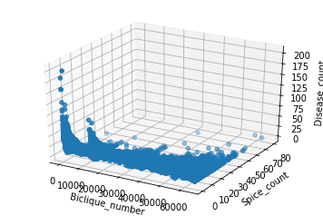

```python
import pandas as pd
from pandas import DataFrame
import matplotlib.pyplot as plt
from mpl_toolkits.mplot3d import Axes3D
df = pd.read_csv('data_for_3Dplot.csv', parse_dates=True)
print(df.head())
threedee = plt.figure().gca(projection='3d')
threedee.scatter(df.Biclique_number, df.Spice_count, df.Disease_count)
threedee.set_xlabel('Biclique_number')
threedee.set_ylabel('Spice_count')
threedee.set_zlabel('Disease_count')
plt.show()
```